# Project Report

Author

Alanda Zong, Juno Park, Luke Lilienthal

Published

May 23, 2023

Abstract

*Cancer diagnosis is an imperfect art that requires invasive tests to be exceedingly accurate. Without these, there is subjectivity and opinion in the professionals that hope to identify physical patterns. In this report, we create a ML model that is capable of identifying malignant tumors using physical characteristics with both high recall and accuracy. We achieve this through the implimentation of boosting techniques, primarilt AdaBoost. Through implimentation of this model, we hope to provide medical professionals with a non-invasive and cheap method with which to routinely analyze tumors using medical imaging*.

## 1 Background / Motivation

We were motivated to choose cancer research because we wanted to do a project on code that may really help people. Through our findings, we may have the opportunity to unravel complex patterns between characteristics of a tumor that may give cancer patients peace of mind if the tumor is malignant or benign.

## 2 Problem statement

It may be difficult to classify tumor types without complex and invasive tests. We want to be able to accurately classify tumors as malignant or not based on surface level medical observations like length, mass and texture with a low rate of false negatives.

## 3 Data sources

We used a dataset concerning cancer tumor types. Here is the link: https://www.kaggle.com/datasets/erdemtaha/cancer-data.

There are 569 rows of data and 32 total columns, but we dropped the response column and the “id” column, so we used 30 total predictors. There were no nulls in the data, and the only categorical column was our response variable, so we converted Malignant to 1 and Benign to 0. The predictors were all numerical data about the tumor itself. All our predictors have either _se, _worst, or _mean. _se represents standard error, _worst represents the highest value of the tumor for that measurement, and _mean represents the mean value [1]. For example, we have two predictors radius_se and radius_worst. Radius_se represents the estimated standard error for the radius of the tumor, and radius_wrost represents the highest value of the tumor radius range that was taken.

## 4 Stakeholders

The stakeholders are medical professionals and people who are affected by cancer. This would benefit them because it would give the stakeholders a clearer idea of if a tumor is likely to be malignant without invasive tests. While more complete tests are likely to follow, an understanding of liklihood patterns will help professionals to better prioritize medical resources based on tumor characteristics.

## 5 Data quality check / cleaning / preparation

```
B    0.627417
M    0.372583
Name: diagnosis, dtype: float64
```

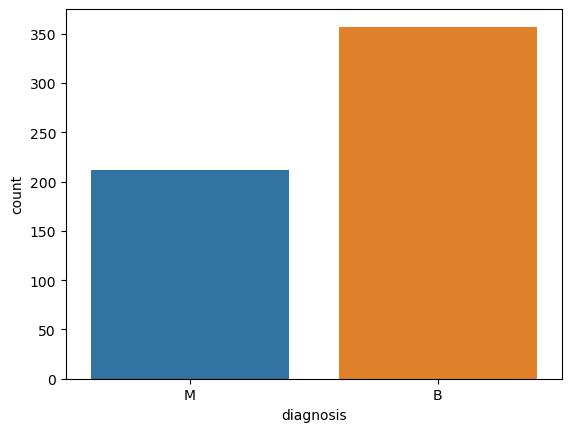

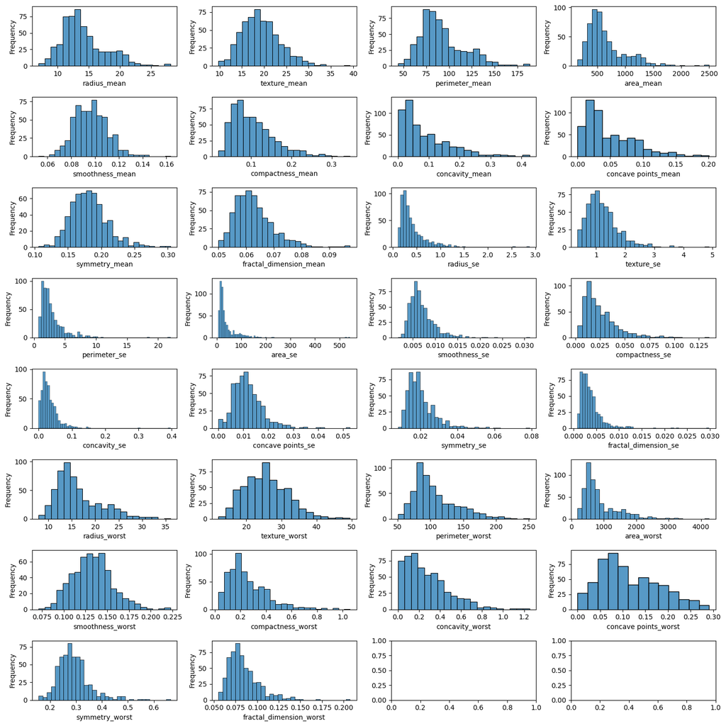

During the data quality check, no useful insights were obtained that would have directly contributed to the development of the model or identified the need for data cleaning/preparation.

We did not create any new predictors from existing predictors.

## 6 Exploratory data analysis

### 6.1 Correlation Analysis

*By Luke Lilienthal*

When we group by predictor type (eg. area), we do see a correlation relationship that is consistent across all types. This relationship is shown in the heatmap below. In all, we expect for _mean and _worst attributes of predictor types to carry similar information in general.

```python
area = data[['area_mean', 'area_se', 'area_worst']]
sns.heatmap(area.corr())
plt.show()
```

[figure not shown]

[figure not shown]

[figure not shown]

Further, when considering correlations across types, we see strong relationships between size metrics (area, radius, perimeter). See heatmap below.

```python
drops = data.drop(columns=['area_worst', 'radius_worst', 'texture_worst', 'perimeter_worst', 'smoothness_worst', 'compactness_worst',
                           'concavity_worst', 'concave points_worst', 'symmetry_worst', 'fractal_dimension_worst'], axis=1)
sns.heatmap(drops.corr())
plt.show()
```

[figure not shown]

## 7 Approach

We used all availible models- focusing on boosting classifers due to their complexity and accuracy. Our goal for a patient-friendly model was to maximize recall. We wanted to be sure that no one would forgo care that they did need in reality as a result of an errored prediction. With recall maximized, we then focused on accuracy in order to create the most cost and care-effective diagnosis tool for medical professionals and insurance companies.

We anticipated that unbalanced class results could skew results across members if we were not careful about random seeds. Further, we were unsure of the effects that stratifying would have. When both stratified and non-stratified results were compares, however, we did not see large differences in the metrics of interest.

There were a few solutions on Kaggle that claimed up to 99% accuracy and 100% precision. Our model build on these by considering recall as a primary optimization metric and accuracy as a secondary metric. While out model did not reach the accuracy of the previous solutions, we are able to present a different approach in terms of modeling goals that adds a dimension to the existing set of solutions.

## 8 Developing the model: Hyperparameter tuning

### 8.1 Decision Tree

*By Juno Park*

```python
# grid of hyperparameter values for initial search
param_grid = {
    'max_depth': range(2,5),
    'max_leaf_nodes': range(2,14),
    'max_features': range(1, 32)
}
```

Optimal Hyperparameter Values = {‘max_depth’: 2, ‘max_features’: 2, ‘max_leaf_nodes’: 3}

The results of the initial grid search made it clear that a further, more detailed search to tune the hyperparameters was unnecessary. This conclusion was reached based on the maximum values obtained for the max_depth and the max_leaf_nodes parameters from the initial decision tree model. Since my grid took into account all values up to these maximums, and the range of max_features was explored thoroughly from 1 to the total number of predictors in the dataset, I was confident in the optimality of the hyperparameter values derived from this first search. Consequently, an additional finely-tuned hyperparameter grid search was deemed superfluous.

Results: - Recall = 93.859% - Accuracy = 88.095%

### 8.2 Bagged Trees

*By Juno Park*

```python
# grid of hyperparameter values for initial search
params = {'base_estimator': [DecisionTreeClassifier(random_state = 1)],
          'n_estimators': [150,200,250],
          'max_samples': [0.5, 0.75, 1.0],
          'max_features': [0.5, 0.75, 1.0],
          'bootstrap': [True, False],
          'bootstrap_features': [True, False]}
```

Optimal Hyperparameter Values = {‘base_estimator’: DecisionTreeClassifier(random_state=1), ‘bootstrap’: True, ‘bootstrap_features’: True, ‘max_features’: 0.5, ‘max_samples’: 1.0, ‘n_estimators’: 200}

The initial grid search yielded optimal hyperparameter values that served as a basis for further refining the hyperparameters in another round of grid search. Specifically, the n_estimators parameter, which had an optimal value of 200 in the first search, prompted a reduced range to focus on values in close proximity. Similarly, the max_samples parameter showed an optimal value of 1.0, leading to the selection of values within a narrow range around 1.0 in the subsequent search. The max_features parameter had an initial optimal value of 0.5, which dictated a narrowed range in the following search to focus on values near this midpoint. Additionally, I decided to decrease the step size between various hyperparameter values in the grid. This finer granularity would facilitate the exploration of a greater number of values within these reduced ranges.

```python
# grid of hyperparamter values for finer grid search
params = {'base_estimator': [DecisionTreeClassifier(random_state = 1)],
          'n_estimators': [180, 190, 200, 210, 220],
          'max_samples': [0.9, 0.95, 1.0],
          'max_features': [0.4, 0.45, 0.5, 0.65, 0.7],
          'bootstrap': [True, False],
          'bootstrap_features': [True, False]}
```

Results with threshold 0.24: - Recall = 94.736% - Accuracy = 92.857%

## 9 RandomForest

*By Luke Lilienthal*

```python
#Cosrse grid search
params = {'bootstrap': [False, True],
         'max_features': [0.3, 0.5, 0.8],
          'max_depth': [12,15,18],
          'max_leaf_nodes':[1100,1200,1300]}
```

Optimal params:

{n_estimators=500, max_features=0.5, bootstrap=True, max_depth=12, max_leaf_nodes=1100}

Based on these results, another a few more grid searches were required with lower values of max_depth and max_leaf_nodes.

```python
#Fine grid search
params = {'bootstrap': [False, True],
         'max_features': [0.35, 0.4, 0.45],
          'max_depth': [5, 6, 7],
          'max_leaf_nodes':[500,600, 700]}
```

Optimal params:

{n_estimators=500, max_features=0.4, bootstrap=True, max_depth=6, max_leaf_nodes=500}

Results with threshold 0.34: - Recall = 90.48% - Accuracy = 94.74%

## 10 AdaBoost

*By Luke Lilienthal*

```python
# Coarse grid search
grid['n_estimators'] = [10, 50, 100,200,500]
grid['learning_rate'] = [0.0001, 0.001, 0.01,0.1, 1.0]
grid['base_estimator'] = [DecisionTreeClassifier(max_depth=1), DecisionTreeClassifier(max_depth=2),
                          DecisionTreeClassifier(max_depth=3),DecisionTreeClassifier(max_depth=4)]
```

Optimal params:

{DecisionTreeClassifier(max_depth=1), learning_rate=1, n_estimators=200}

Based on these results, another a few more grid searches were required more closely clustered values of n_estimators around 200.

```python
# Fine grid search
grid['n_estimators'] = np.arange(100, 300, 10)
grid['learning_rate'] = [1.0]
grid['base_estimator'] = [DecisionTreeClassifier(max_depth=1)]
```

Optimal params:

{DecisionTreeClassifier(max_depth=1), learning_rate=1, n_estimators=190}

Results with threshold 0.45: - Recall = 100% - Accuracy = 97.37%

### 10.1 Gradient Boost

*By Alanda Zong*

```python
#initial grid search
grid = dict()
grid['n_estimators'] = [10, 50, 100,200,500]
grid['learning_rate'] = [0.0001, 0.001, 0.01,0.1, 1.0]
grid['max_depth'] = [1,2,3,4,5]
grid['subsample'] = [0.5,1.0]

#finer grid search
grid = dict()
grid['n_estimators'] = [500, 550]
grid['learning_rate'] = [0.1, 0.5]
grid['max_depth'] = [3]
grid['subsample'] = [1.0, 1.5]
```

optimal parameters: {‘learning_rate’: 0.1, ‘max_depth’: 3, ‘n_estimators’: 500, ‘subsample’: 1.0}

Results with threshold 0.01: - Accuracy: 97.36842105263158 - Recall: 0.9285714285714286

For the finer grid search of my gradient boost model, since my computer is old and only has two processors, anytime I add more numbers into my parameter grid, it takes an exponentially long time to run. Therefore, I used the initial grid search and let it run for a while. Then, I used a finer search to look at the options of the best params and just switched them out, so I never exceeded more than 2 choices for each parameter. So after many trials with switching out parameter numbers, I ended with the parameters above.

### 10.2 XGBoost

*By Alanda Zong*

```python
#initial search:
param_grid = {'n_estimators':[100,400],
                'max_depth': [1, 5],
              'learning_rate': [0.01,0.1],
               'gamma': [0.1,0.25],
               'reg_lambda':[0.01,0.001],
                'scale_pos_weight':[1.25,1.5]
             }


#finer grid search
param_grid = {'n_estimators':[100, 125],
                'max_depth': [4, 5],
              'learning_rate': [0.5, 0.6],
               'gamma': [0.45, 0.5],
               'reg_lambda':[0.001, 0.003],
                'scale_pos_weight':[1.25]
             }
```

optimal parameters: {‘gamma’: 0.5, ‘learning_rate’: 0.5, ‘max_depth’: 5, ‘n_estimators’: 100, ‘reg_lambda’: 0.001, ‘scale_pos_weight’: 1.25}

This follows the same approach as the GradientBoost model because this was done on the same computer with two processors. I used the initial grid search and let it run for a while. Then, I used a finer search to look at the options of the best params and just switched them out, so I never exceeded more than 2 choices for each parameter. So after many trials with switching out parameter numbers, I ended with the parameters above.

Results with threshold 0.13:

- Accuracy: 96.49122807017544
- Recall: 0.9523809523809523

## 11 Model Ensemble

### 11.1 Voting ensemble

Base models of AdaBoost, XGBoost, and Bagged DecisionTrees

With threshold 0.31: - Recall = 95.24% - Accuracy = 96.49%

While these results are better than most base models, they do not surpas the performance of our best individual model AdaBoost.

### 11.2 Stacking ensemble

Base models of AdaBoost, XGBoost, and Bagged DecisionTrees

Best final estimator: LogisticRegression()

With threshold 0.13: - Recall = 95.24% - Accuracy = 96.49%

These results are the same as voting ensemble and again worse than AdaBoost. It seems that we have one dominant model in our solution set that makes ensembling not particularly effective.

## 12 Limitations of the model with regard to prediction

Our evaluations are done on a singular threshold value for each model. We chose recall as our threshold; however, there is a trade off for accuracy and recall, and we could’ve gotten our models to have more accuracy.

While we did run comprehensive tuning on our models, it is absolutely possible that the models could be further tuned to improve their performance. Or, there may be potentially better configurations of our hyperparameters.

## 13 Conclusions and Recommendations to stakeholder(s)

In general, we conclude that an ML boosting model is very applicable to supplementing the diagnoses of medical professionals due to the high levels of test accuracy and recall that we were able to achieve. Our main recomendation is that initial/routine cancer sceenings should be done using the model produced to save time and money for both medical professionals and patients. We believe this to be very applicable due to the ease of computational strain for running the single model and the accuracy that it produces. Because the recall is very high, we feel comfortable recomending patients to put trust in this technique to identify their health statuses. We do not believe that this model will become less accurate over time, but changes in cancer types and shapes could impact its usefulness.

## Individual contribution

| Team member | Individual Model | Work other than individual model | Details of work other than individual model |
| --- | --- | --- | --- |
| Luke Lilienthal | RandomForest & AdaBoost | Correlation Analysis and Ensembling | Found feature colinearity and voting/stacking ensembles |
| Alanda Zong | GradientBoost and XGBoost | Research about predictors | We were unsure about some of our predictors, so I did research into the meanings of _se, _mean, and _worst that came with our predictors |
| Juno Park | Decision Tree and Bagging | Data Visualizations | Created plots to visualize the response variables and all the othe predictors |

## References

[1] https://www.ncbi.nlm.nih.gov/pmc/articles/PMC7349542/